# GOcategoryStats

This vignette shows examples of exploring a set of genes using the GOcategoryStats package.

```r
library("devtools")
load_all("C:/Users/bigginsl/Documents/GOcategoryStats")
```

```
Loading GOcategoryStats
```

The datasets m_musculus, bg_genes and genes_1 are included in the GOcategoryStats package. genes_1 is a set of 100 genes that can be used as a set of query genes of interest. m_musculus is a dataset containing gene annotations from Ensembl for the mouse genome.

We need some gene information that we’ll get from a gtf file

1. Check the genes against a background set. Produce the plots from gene screen.
2. overrepresentation test
3. explore the top GO category results - would be nice to have a brief summary of these - can we plot them neatly?

```r
head(m_musculus)

gene_info_all <- process_GTF(m_musculus)
gene_info <- remove_duplicates(gene_info_all, column=6)
head(gene_info)

genes_1 <- remove_duplicates(genes_1)

genes_1 <- toupper(genes_1)
bg_genes <- toupper(bg_genes)

genes_filt <- genes_1[genes_1 %in% bg_genes]
```

89 query genes were found in the background set. Those that did not match were removed.

Plot the length of all the genes.

```r
sum(!genes_filt %in% gene_info$gene_name)

# plot lengths
query_lengths <- get_lengths(genes_filt, gene_info)
bg_lengths <- get_lengths(bg_genes, gene_info)

my_plotting_data <- list(query=query_lengths, background=bg_lengths)
density_plot(my_plotting_data, log=TRUE, main ="gene lengths")
```

[output not shown]

Plot which chromosome the genes are on.

```r
query_chr <- get_chromosomes(genes_filt, gene_info)
bg_chr <- get_chromosomes(bg_genes, gene_info)

chr_list <- list(query=query_chr, background=bg_chr)

chr_proportions <- get_chr_percentage(chr_list)

bar_plot(chr_proportions, main= "chr")
```

[output not shown]

Another way of viewing the same data

```r
bar_plot(chr_proportions, main= "chr", plot_differences = TRUE)
```

[output not shown]

## Functional analysis

Do an overrepresentation test to see which gene ontology categories are overrpresented in the data

```r
go_res <- overrep_test(list_of_categories = ontology_categories, query_genes = genes_1, bg_genes = bg_genes)
```

```
Error in FUN(X[[i]], ...) :
  object 'min_query_genes_in_category' not found
```

Have a look at the genes in the categories and see how the plots look.

Look up the genes from the category

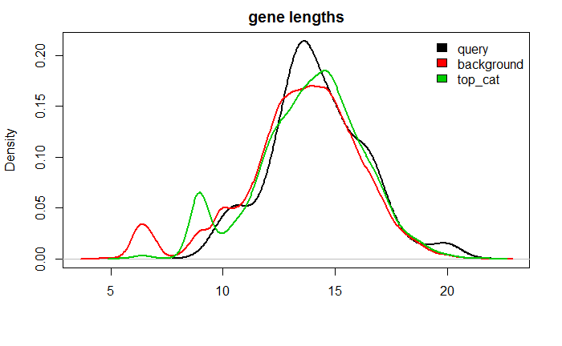

```r
#get_GO_info <- function(selected_go_names, all_go_categories, gtf)
selected_go <- rownames(go_res)[1:5]
x <- get_GO_info(selected_go, ontology_categories, m_musculus)

# get the genes from the top category
top_cat <- get_GO_sets(rownames(go_res)[1], all_go_categories)
top_cat <- top_cat[[1]]
# plot lengths
query_lengths <- get_lengths(genes_filt, gene_info)
bg_lengths <- get_lengths(bg_genes, gene_info)
top_cat_lengths <- get_lengths(top_cat, gene_info)
my_plotting_data <- list(query=query_lengths, background=bg_lengths, top_cat=top_cat_lengths)
density_plot(my_plotting_data, log=TRUE, main ="gene lengths")
```

[figure not shown]